```python
import tellurium as te

%matplotlib inline
%config InlineBackend.figure_format='retina'
```

# Introduction to Gene Networks

# Biology of Gene Regulation

In order to model genetic networks, we must first understand some of the biological machinery involved.

# Operon: The Fundamental Functional Unit of Prokaryotic Genome

[figure not shown]

- **Promoter**: Initiates transcription
- **Operator(s)**: Areas where **transcription factors** (TF) can bind to control rate of transcription
- **Activator**: TF that increases transcription
- **Repressor**: TF that decreases transcription

# Transcription Factors

May function alone or as a complex of multiple proteins.

# Repression

[figure not shown]

# Activation

### Activation by RNA Polymerase Recruitment

[figure not shown]

# Lac Operon

[figure not shown]

- $\beta$-galactosidase allows *E. coli* to metabolize lactose sugar into glucose and galactose
- Wasteful to produce $\beta$-galactosidase if no lactose present or abundant glucose

While *E. coli* usually prefer glucose as a food source, in the absence of glucose it would be beneficial to be able to metabolize lactose sugar, which can be broken down into glucose and galactose. However, it would also be wasteful for the cell to produce additional enzymes when there is no lactose or if glucose is readily available. The **lac operon** is used in regulating this process.

One of the genetic products of the lac operon is $\beta$-galactosidase, which serves to cleave lactose into glucose and galactose. In normal, high-glucose and low-lactose conditions, *lacI* repressor obstructs RNA polyermase from transcribing the genes in the lac operon. In the presence of lactose, the lactose molecules themselves can sequester *lacI* and promote transcription.

There is second layer of control for the lac operon. In the absence of glucose, cyclic AMP (cAMP) levels increase. cAMP forms a complex with the catabolite activator protein (CAP). This complex binds to the promoter and stimulates the transcription.

# Building a Model of the Lac Operon

1. Metabolism of Lactose
2. Regulation of $\beta$-galactosidase

# Breakdown of Lactose by $\beta$-gal

[figure not shown]

```
lac -> glu + gal; (Vm_bGal * lac) / (km_bGal + lac)
                  --------------------------------- Michaelis-Menten rate law
```

# Picking a Rate Law for Enzyme Kinetics

- Michaelis-Menten

$$E + S \underset{k_r}{\overset{k_f}{\rightleftharpoons}} ES \xrightarrow{k_{cat}} E + P $$

$$v = \frac{V_m\:S}{K_m+S}$$

- Assumes irreversible and fast equilbirium

$$\frac{k_{cat}}{k_r} \ll 1$$

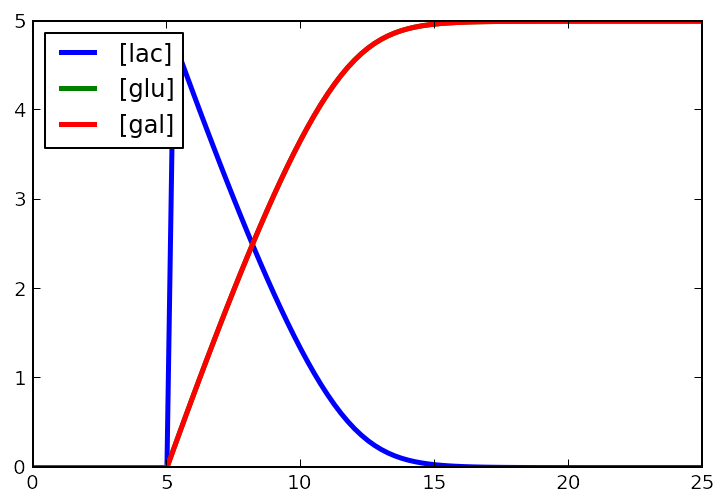

```python
lacBreakdown = '''
# Break down of lactose into glucose and galactose by bGal
lac -> glu + gal; (Vm_bGal * lac) / (km_bGal + lac)

# Species Initialization
lac = 0; gal = 0;
# Parameters
Vm_bGal = 1; km_bGal = 1;

# Injection of lactose at t=5
at (time >5): lac = 5
'''
rr = te.loadAntimonyModel(lacBreakdown)
result = rr.simulate(0, 25, 100)
p = te.plotWithLegend(rr, result)
```

# Production of $\beta$-galactosidase

$\beta$-galactosidase production is regulated by lactose

Lactose binds to and deactivates lac repressor

# Hill Equation

**Cooperative binding**: Binding of ligand (substance that forms a complex with a biomolecule) enhanced by other ligands

Effect quantified with Hill Equation:

$$ v = \frac{Vm\:S^n}{K_d + S^n} $$

- $Vm$: Maximum rate
- $S$: Ligand
- $n$: Hill coefficient
- $K_d$: Dissociation constant

```
-> bGal; (V_max * lac^n / (kd_lac + lac^n))
                            ------------------------- Cooperativity
```

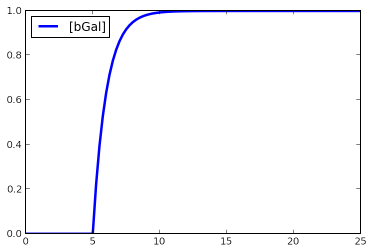

```python
bGalRegulation = '''
-> bGal; (Vm_exp * lac^n / (kd_lac + lac^n)) # Production of bGal
bGal -> ; k_deg * bGal # Degradation of bGal

# Species Initialization
lac = 0;
bGal = 0;
# Parameters
k_deg = 1;
kd_lac = 1;
n = 4;
V_exp = 1;

at (time >5): lac = 5
'''
rr = te.loadAntimonyModel(bGalRegulation)
result = rr.simulate(0, 25, 100)
p = te.plotWithLegend(rr, result)
```

# Full Model

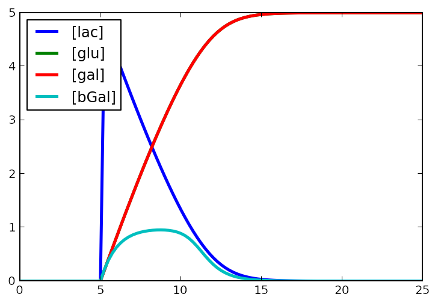

```python
lacOperon = '''
# Break down of lactose into glucose and galactose
lac -> glu + gal; (Vm_bGal * lac) / (km_bGal + lac)
-> bGal; (Vm_exp * lac^n / (kd_lac + lac^n)) # Production of bGal
bGal -> ; k_deg * bGal                                # Degradation of bGal

# Species Initialization
lac = 0; gal = 0; bGal = 0;


# Parameters
Vm_bGal = 1; km_bGal = 1;
k_deg = 1;
kd_lac = 1;
n = 4;
Vm_exp = 1;

at (time >5): lac = 5
'''
rr = te.loadAntimonyModel(lacOperon)
result = rr.simulate(0, 25, 100)
p = te.plotWithLegend(rr, result)
```